# Exam

Ricardo Landolt

2022-06-10

### Overiew

The structure of the data shows that the right datatypes have been used.

```r
str(df)
```

```
## 'data.frame':    9368 obs. of  15 variables:
##  $ Country           : chr  "United States" "United States" "United States" "United States" ...
##  $ CountryCode       : int  2 2 2 2 2 2 2 2 2 2 ...
##  $ Year              : int  1945 1946 1947 1948 1949 1950 1951 1952 1953 1954 ...
##  $ Assassination     : int  0 0 0 0 0 0 0 0 0 0 ...
##  $ CoupAttempts      : int  NA 0 0 0 0 0 0 0 0 0 ...
##  $ POLITY            : int  10 10 10 10 10 10 10 10 10 10 ...
##  $ PartyExclusion    : int  NA 0 0 0 0 0 0 0 0 0 ...
##  $ PercentLiterate   : num  NA 97.1 97.3 97.1 97 96.8 97.2 97.5 97.6 97.7 ...
##  $ UnivEnrollmentPerK: num  NA 11.8 14.8 17.8 17.6 17.5 16 15.2 15.1 15.6 ...
##  $ Population        : int  NA 141389 144126 146631 149188 151683 154630 151028 159636 162417 ...
##  $ GDP               : int  NA 1360 1464 1568 1672 1777 1881 1985 2090 2136 ...
##  $ TotalTrade        : int  NA 10982 15665 15100 13155 13145 17347 17736 16814 15681 ...
##  $ RegimeDurability  : int  136 137 138 139 140 141 142 143 144 145 ...
##  $ YearNumeric       : int  1945 1946 1947 1948 1949 1950 1951 1952 1953 1954 ...
##  $ lntt              : num  NA 9.3 9.66 9.62 9.48 ...
```

```r
summary(df)
```

```
##    Country           CountryCode       Year      Assassination
##  Length:9368        Min.   :  2   Min.   :1945   Min.   :0.0000
##  Class :character   1st Qu.:235   1st Qu.:1969   1st Qu.:0.0000
##  Mode  :character   Median :451   Median :1985   Median :0.0000
##                     Mean   :456   Mean   :1984   Mean   :0.0072
##                     3rd Qu.:663   3rd Qu.:2000   3rd Qu.:0.0000
##                     Max.   :950   Max.   :2014   Max.   :1.0000
##
##   CoupAttempts      POLITY       PartyExclusion PercentLiterate
##  Min.   :0.00   Min.   :-10.00   Min.   :0.0    Min.   :  1.3
##  1st Qu.:0.00   1st Qu.: -7.00   1st Qu.:0.0    1st Qu.: 42.9
##  Median :0.00   Median :  0.00   Median :1.0    Median : 74.4
##  Mean   :0.03   Mean   :  0.63   Mean   :1.4    Mean   : 66.7
##  3rd Qu.:0.00   3rd Qu.:  8.00   3rd Qu.:3.0    3rd Qu.: 95.0
##  Max.   :5.00   Max.   : 10.00   Max.   :3.0    Max.   :110.7
##  NA's   :73     NA's   :111      NA's   :1224   NA's   :1988
##  UnivEnrollmentPerK   Population           GDP           TotalTrade
##  Min.   :  0.0      Min.   :    113   Min.   :    21   Min.   :      34
##  1st Qu.:  1.8      1st Qu.:   3026   1st Qu.:   266   1st Qu.:   10062
##  Median :  6.0      Median :   7786   Median :   791   Median :   38298
##  Mean   : 11.9      Mean   :  32802   Mean   :  4120   Mean   :  279128
##  3rd Qu.: 18.3      3rd Qu.:  20706   3rd Qu.:  2935   3rd Qu.:  169134
##  Max.   :125.3      Max.   :1354503   Max.   :118673   Max.   :10261570
##  NA's   :2368       NA's   :929       NA's   :1649     NA's   :1660
##  RegimeDurability  YearNumeric        lntt
##  Min.   :  0.0    Min.   :1945   Min.   : 3.5
##  1st Qu.:  4.0    1st Qu.:1969   1st Qu.: 9.2
##  Median : 12.0    Median :1985   Median :10.6
##  Mean   : 21.6    Mean   :1984   Mean   :10.7
##  3rd Qu.: 28.0    3rd Qu.:2000   3rd Qu.:12.0
##  Max.   :205.0    Max.   :2014   Max.   :16.1
##  NA's   :31                      NA's   :1660
```

The hist plot shows that it is not a balanced dataset.

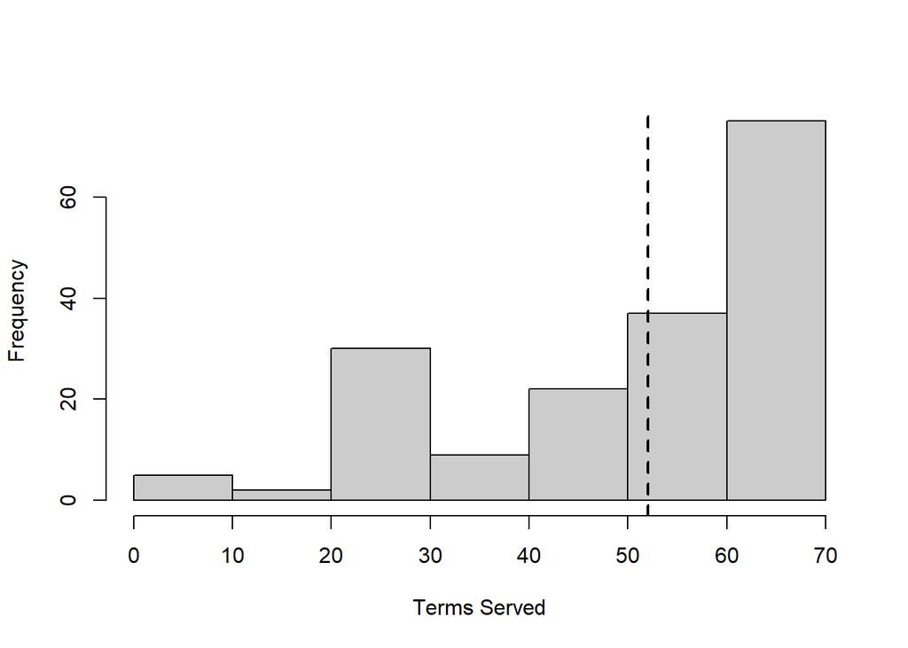

```r
dfyear<-ddply(df,.(CountryCode),summarise,
             Terms=n())

hist(dfyear$Terms,col="grey80",freq=TRUE,
     main="",xlab="Terms Served")
abline(v=mean(dfyear$Terms),lwd=2,lty=2)
```

There are a lot of missing values, which probalby will influence the results. However, these are not considered further for this exam.

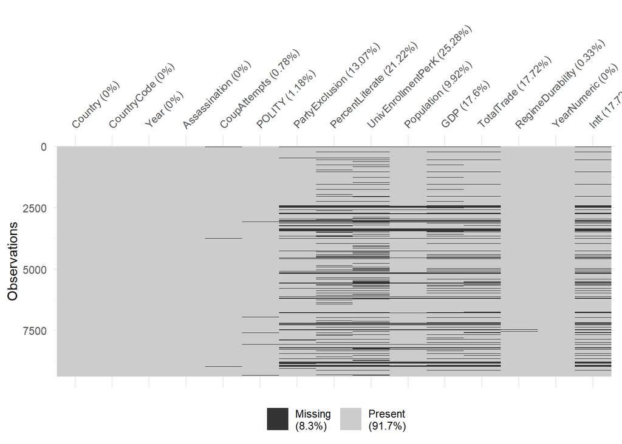

```r
vis_miss(df)
```

## Do regimes which exclude opposition parties last longer?

If a regime exclude opposition parties in the bivariate and in the ols model the RegimeDurability variable decreases. The opposite is the case with the Fixed Effect models, which can make sense, because if other parties are excluded, they have no chance of coming to power. It can also be determined by observing the coefficients that in the ols and in the one-way fixed effect model the variables PercentLiterate and the GDP have a positive, whereas the CoupAttempts has a negative effect on the dependent variable. In comparison, the two-way fixed effect model and the model which includes a lagged dependent variable differ by the variable percent literate, which has a negative or near zero coefficient. A possible explanation could be that a country with more educated people, is probably more modern and liberal. One can assume that a more liberal country allows much more variety of parties and is more open to an alternative political direction. e.g. one can think of the usa, germany and france, where from time to time a shift from left to right took place. In a non-democratic country, other parties are more likely to be undermined, resulting in fewer changes.

#### OLS, Fixed Effect Models, Lagged Dependent Variable

```r
BIV<-lm(RegimeDurability~PartyExclusion,data=pddf)

# OLS:
OLS<-lm(RegimeDurability~PartyExclusion +PercentLiterate +CoupAttempts  +
GDP ,data=pddf)

# Fixed Effects... One-way:
FE.1way<-plm(RegimeDurability~PartyExclusion + +PercentLiterate +CoupAttempts +
GDP,data=pddf,effect="individual",model="within")

# Two-way:
FE.2way<-plm(RegimeDurability~PartyExclusion +PercentLiterate +CoupAttempts  +
GDP,data=pddf,effect="twoway",model="within")

FE.LDV<-plm(RegimeDurability~PartyExclusion + PercentLiterate +CoupAttempts+GDP+  lag(RegimeDurability),data=pddf,effect="individual",model="within")


stargazer(BIV,OLS,FE.1way,FE.2way,FE.LDV, type = "html")
```

|  | *Dependent variable:* |  |  |  |  |
| --- | --- | --- | --- | --- | --- |
|  | RegimeDurability |  |  |  |  |
|  | *OLS* |  | *panel* |  |  |
|  |  |  | *linear* |  |  |
|  | (1) | (2) | (3) | (4) | (5) |
| PartyExclusion | -18.440*** | -9.839*** | 6.533*** | 6.703*** | 0.178 |
|  | (0.636) | (0.706) | (0.486) | (0.487) | (0.197) |
| PercentLiterate |  | 0.070*** | 0.146*** | -0.094*** | 0.001 |
|  |  | (0.012) | (0.010) | (0.018) | (0.004) |
| CoupAttempts |  | -2.839** | -1.040* | -1.097* | -1.163*** |
|  |  | (1.326) | (0.611) | (0.597) | (0.242) |
| GDP |  | 0.001*** | 0.001*** | 0.001*** | 0.0001*** |
|  |  | (0.00004) | (0.00002) | (0.00003) | (0.00001) |
| lag(RegimeDurability) |  |  |  |  | 0.920*** |
|  |  |  |  |  | (0.005) |
| Constant | 34.140*** | 18.850*** |  |  |  |
|  | (0.507) | (1.094) |  |  |  |
| Observations | 8,126 | 7,128 | 7,128 | 7,128 | 7,061 |
| R<sup>2</sup> | 0.094 | 0.246 | 0.286 | 0.169 | 0.889 |
| Adjusted R<sup>2</sup> | 0.094 | 0.245 | 0.269 | 0.142 | 0.886 |
| Residual Std. Error | 27.590 (df = 8124) | 24.830 (df = 7123) |  |  |  |
| F Statistic | 840.500*** (df = 1; 8124) | 580.200*** (df = 4; 7123) | 695.800*** (df = 4; 6964) | 351.600*** (df = 4; 6900) | 11,010.000*** (df = 5; 6896) |
| *Note:* | p<0.1; p<0.05; p<0.01 |  |  |  |  |

#### Covariate Balance

##### Covariate Balance before matching

The variables CoupAttempts, PercentLiterate and GDP were divided into 10 deciles and a covariance plot is shown below. The points are not on the vertical line for almost any of the variable indicators. So it can be said, the regimes that exclude other parties are very different from the regimes that do not exclude other parties.

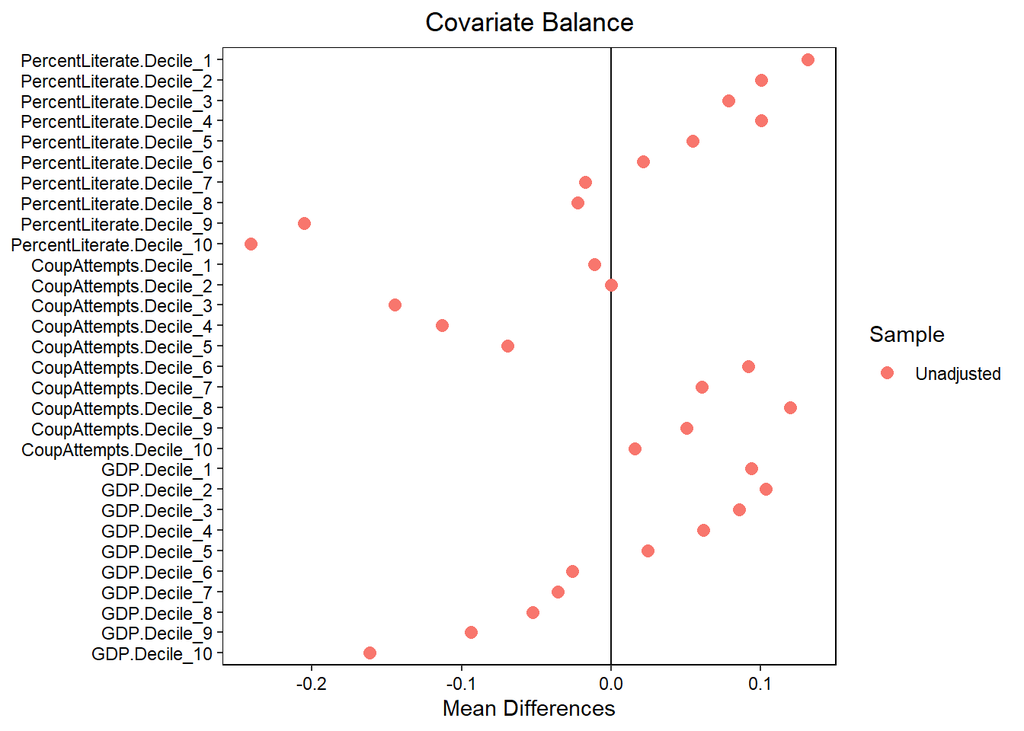

```r
vars<-c("CountryCode","Year","RegimeDurability","PartyExclusion","PercentLiterate","GDP","TotalTrade","CoupAttempts","YearNumeric","UnivEnrollmentPerK",  "lntt")
pddf<-pddf[vars]
pddf<-na.omit(pddf)
# Create discrete-valued variables (i.e., coarsen) for
# matching on continuous predictors:

pddf$CoupAttempts.Decile<-as.factor(ntile(pddf$CoupAttempts,10))
pddf$PercentLiterate.Decile<-as.factor(ntile(pddf$PercentLiterate,10))
pddf$GDP.Decile <-as.factor(ntile(pddf$GDP,10))

# Pre-match balance statistics...
BeforeBal<-bal.tab(PartyExclusion ~
                PercentLiterate.Decile + CoupAttempts.Decile  +GDP.Decile ,data=pddf,
                stats=c("mean.diffs","ks.statistics"))

# Plot balance:
plot(BeforeBal)
```

```r
# Exact Matching:
M.exact <- matchit(PartyExclusion~
                PercentLiterate.Decile+CoupAttempts.Decile + GDP.Decile ,data=pddf,method="exact")

# Plot balance...
ExactBal<-bal.tab(M.exact,un=TRUE)
pddf.exact <- match.data(M.exact,group="all")
```

##### Covariate Balance after matching

In order to compare regimes which exclude other parties with the ones that don’t exclude them, an exact matching approach has been used. As an aside, one would like to mention at this point that matching with propensity score and optimal was also attempted, but the results were not satisfactory. In order not to lengthen the report, they are not listed. This procedure changes the number of rows from 6500 to 3457.

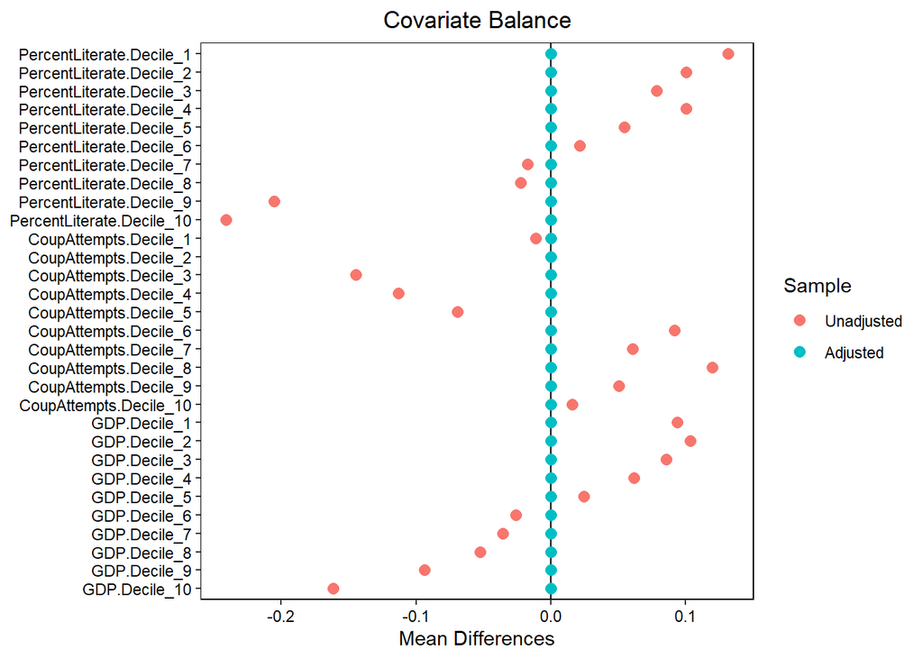

```r
plot(ExactBal)
```

#### Model comparsion Matching

Comparing the regressions before and after matching, confirms the statements above, the coefficients change slightly due to the consideration of matching.

```r
# Regressions (before and) after matching... ####

PreMatch.FE<-plm(RegimeDurability~PartyExclusion + PercentLiterate +CoupAttempts +
GDP ,data=pddf, effect="individual",model="within")

PreMatch.FE.LDV<-plm(RegimeDurability~PartyExclusion + PercentLiterate +CoupAttempts  + GDP +  lag(RegimeDurability),data=pddf,
            effect="individual",model="within")

FE.Exact <-plm(RegimeDurability~PartyExclusion + PercentLiterate +CoupAttempts  + GDP,data=pddf.exact,effect="individual",model="within")

FE.LDV.Exact <-plm(RegimeDurability~PartyExclusion + PercentLiterate + CoupAttempts  + GDP + lag(RegimeDurability),data=pddf.exact,
              effect="individual",model="within")


stargazer(PreMatch.FE,PreMatch.FE.LDV,FE.Exact,FE.LDV.Exact, type = "html")
```

|  | *Dependent variable:* |  |  |  |
| --- | --- | --- | --- | --- |
|  | RegimeDurability |  |  |  |
|  | (1) | (2) | (3) | (4) |
| PartyExclusion | 6.313*** | 0.217 | 5.296*** | -0.059 |
|  | (0.487) | (0.194) | (0.610) | (0.264) |
| PercentLiterate | 0.123*** | 0.001 | 0.082*** | -0.006 |
|  | (0.011) | (0.004) | (0.017) | (0.008) |
| CoupAttempts | -1.200* | -1.490*** | -1.644 | -1.772*** |
|  | (0.616) | (0.240) | (1.010) | (0.443) |
| GDP | 0.001*** | 0.0001*** | 0.001*** | 0.0001*** |
|  | (0.00002) | (0.00001) | (0.0001) | (0.00003) |
| lag(RegimeDurability) |  | 0.919*** |  | 0.920*** |
|  |  | (0.005) |  | (0.008) |
| Observations | 6,500 | 6,280 | 3,457 | 3,052 |
| R<sup>2</sup> | 0.300 | 0.896 | 0.130 | 0.859 |
| Adjusted R<sup>2</sup> | 0.282 | 0.893 | 0.091 | 0.853 |
| F Statistic | 679.800*** (df = 4; 6338) | 10,517.000*** (df = 5; 6124) | 123.500*** (df = 4; 3306) | 3,560.000*** (df = 5; 2911) |
| *Note:* | p<0.1; p<0.05; p<0.01 |  |  |  |

#### Differences in Differences

There are some countries that change their behaviour in including or excluding other parties over time, because of that it could make sense to try a differences in differences approach. Looking at the graph below, the color of the lines represent the countries. If the line is shaped with triangles, the regime excludes other parties whereas if the line is shaped with circles it doesn’t exclude other parties.

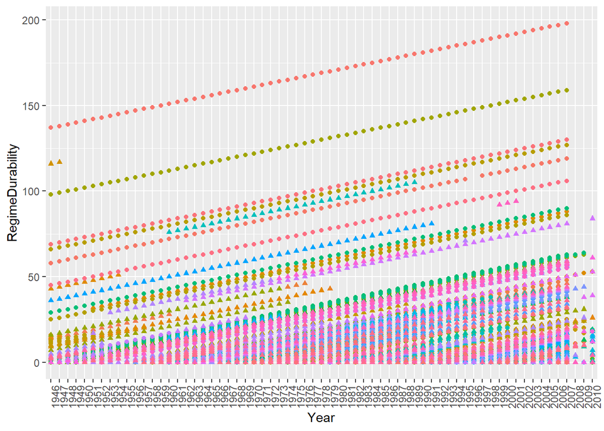

```r
ggplot(pddf , aes(x = Year , y = RegimeDurability, colour =CountryCode, shape = factor(PartyExclusion) )) +
  geom_point() +
  theme(legend.position="none", axis.text.x = element_text(angle = 90))
```

The summary below shows that all models with fixed effect have a positive partyexclusion and a negative percentliterate coefficient, which cover the statements from above.

```r
pddf.exact$Time<-pddf.exact$YearNumeric-1950

OLS1<-lm(RegimeDurability~PartyExclusion  + Time +PartyExclusion*Time,data=pddf.exact)

OLS2<-lm(RegimeDurability~PartyExclusion + PercentLiterate + CoupAttempts  + GDP + Time +PartyExclusion*Time,
             data=pddf.exact)

oneway.1<-plm(RegimeDurability~PartyExclusion  + Time +PartyExclusion*Time,data=pddf.exact,
              effect="individual",model="within")

oneway.2 <-plm(RegimeDurability~PartyExclusion + PercentLiterate + CoupAttempts  + GDP + Time +PartyExclusion*Time,
               data=pddf.exact,effect="individual",model="within")

twoway.1 <-plm(RegimeDurability~PartyExclusion  + Time +PartyExclusion*Time,data=pddf.exact,
                effect="twoway",model="within")

twoway.2 <-plm(RegimeDurability~PartyExclusion + PercentLiterate + CoupAttempts  + GDP + Time +PartyExclusion*Time,
                data=pddf.exact,effect="twoway",model="within")


modelsummary(list(OLS1,OLS2,oneway.1,oneway.2,
                      twoway.1,twoway.2))
```

|  | Model 1 | Model 2 | Model 3 | Model 4 | Model 5 | Model 6 |
| --- | --- | --- | --- | --- | --- | --- |
| (Intercept) | 27.619 | 22.129 |  |  |  |  |
|  | (1.293) | (1.706) |  |  |  |  |
| PartyExclusion | −14.323 | −10.790 | 16.376 | 10.522 | 15.658 | 9.900 |
|  | (1.655) | (1.664) | (1.287) | (1.335) | (1.302) | (1.350) |
| Time | −0.184 | −0.257 | 0.429 | 0.414 |  |  |
|  | (0.033) | (0.032) | (0.024) | (0.034) |  |  |
| PartyExclusion × Time | 0.226 | 0.196 | −0.244 | −0.109 | −0.263 | −0.130 |
|  | (0.043) | (0.043) | (0.031) | (0.032) | (0.031) | (0.032) |
| PercentLiterate |  | 0.062 |  | −0.205 |  | −0.183 |
|  |  | (0.014) |  | (0.031) |  | (0.032) |
| CoupAttempts |  | −2.199 |  | −1.682 |  | −1.574 |
|  |  | (1.797) |  | (0.986) |  | (0.990) |
| GDP |  | 0.001 |  | 0.001 |  | 0.001 |
|  |  | (0.000) |  | (0.000) |  | (0.000) |
| Num.Obs. | 3457 | 3457 | 3457 | 3457 | 3457 | 3457 |
| R2 | 0.031 | 0.100 | 0.128 | 0.171 | 0.047 | 0.093 |
| R2 Adj. | 0.031 | 0.098 | 0.089 | 0.133 | −0.015 | 0.033 |
| AIC | 30800.3 | 30552.8 | 26145.4 | 25977.8 | 25999.3 | 25834.3 |
| BIC | 30831.1 | 30602.0 | 26145.5 | 25971.9 | 26001.5 | 25830.5 |
| F | 37.404 | 63.854 |  |  |  |  |
| RMSE | 20.79 | 20.04 | 10.61 | 10.34 | 10.39 | 10.13 |

```r
pedf <-pddf %>%
  group_by(CountryCode) %>%
  filter(any(PartyExclusion==1))

pedf <-pdata.frame(pedf,index=c("CountryCode","Year"))

pedf$Time<-pedf$YearNumeric-1950

OLS1 <-lm(RegimeDurability~PartyExclusion  + Time +PartyExclusion*Time,data=pddf.exact)

OLS2 <-lm(RegimeDurability~PartyExclusion + PercentLiterate + CoupAttempts  + GDP + Time +PartyExclusion*Time,
             data=pedf)

oneway.1 <-plm(RegimeDurability~PartyExclusion  + Time +PartyExclusion*Time,data=pedf,
              effect="individual",model="within")

oneway.2<-plm(RegimeDurability~PartyExclusion + PercentLiterate + CoupAttempts  + GDP + Time +PartyExclusion*Time,
               data=pddf.exact,effect="individual",model="within")

twoway.1 <-plm(RegimeDurability~PartyExclusion  + Time +PartyExclusion*Time,data=pedf,
                effect="twoway",model="within")

twoway.2 <-plm(RegimeDurability~PartyExclusion + PercentLiterate + CoupAttempts  + GDP + Time +PartyExclusion*Time,
                data=pedf,effect="twoway",model="within")

modelsummary(list(OLS1,OLS2,oneway.1,oneway.2,
                      twoway.1,twoway.2))
```

|  | Model 1 | Model 2 | Model 3 | Model 4 | Model 5 | Model 6 |
| --- | --- | --- | --- | --- | --- | --- |
| (Intercept) | 27.619 | 9.312 |  |  |  |  |
|  | (1.293) | (1.417) |  |  |  |  |
| PartyExclusion | −14.323 | 1.649 | 6.625 | 10.522 | 6.921 | 5.905 |
|  | (1.655) | (1.413) | (1.142) | (1.335) | (1.151) | (1.153) |
| Time | −0.184 | 0.051 | 0.212 | 0.414 |  |  |
|  | (0.033) | (0.031) | (0.024) | (0.034) |  |  |
| PartyExclusion × Time | 0.226 | 0.001 | 0.013 | −0.109 | −0.007 | 0.014 |
|  | (0.043) | (0.034) | (0.028) | (0.032) | (0.028) | (0.028) |
| PercentLiterate |  | 0.021 |  | −0.205 |  | −0.048 |
|  |  | (0.009) |  | (0.031) |  | (0.023) |
| CoupAttempts |  | −2.686 |  | −1.682 |  | −1.172 |
|  |  | (0.912) |  | (0.986) |  | (0.639) |
| GDP |  | 0.001 |  | 0.001 |  | 0.001 |
|  |  | (0.000) |  | (0.000) |  | (0.000) |
| Num.Obs. | 3457 | 5133 | 5133 | 3457 | 5133 | 5133 |
| R2 | 0.031 | 0.046 | 0.092 | 0.171 | 0.031 | 0.051 |
| R2 Adj. | 0.031 | 0.045 | 0.069 | 0.133 | −0.006 | 0.014 |
| AIC | 30800.3 | 43013.3 | 39103.7 | 25977.8 | 38966.0 | 38864.7 |
| BIC | 30831.1 | 43065.6 | 39104.3 | 25971.9 | 38968.5 | 38861.2 |
| F | 37.404 | 41.461 |  |  |  |  |
| RMSE | 20.79 | 15.95 | 10.91 | 10.34 | 10.76 | 10.65 |

Next, a manual approach is used and so the maximum regime durability per regime and party exclusion was calculated. The longest durability with exclusion and non-exclusion has been calculated. The density plot shows the situation that regimes which excluded parties tend to govern longer.

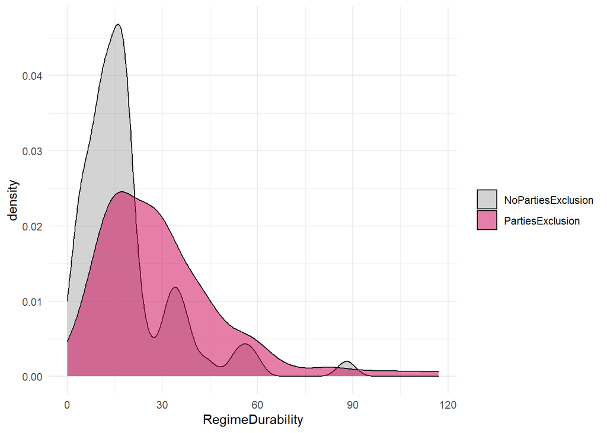

```r
grouped <- pedf %>%
  group_by(CountryCode, PartyExclusion) %>%
  summarise(RegimeDurability  = max(RegimeDurability, na.rm = TRUE) )

ggplot(grouped, aes(x = RegimeDurability, fill = factor(PartyExclusion))) +
  geom_density(alpha = 0.5) + # density plot with transparency (alpha = 0.5)
  scale_fill_manual(name = " ", # changes to fill dimension
                     values = c("#a7a8aa", "#cc0055"),
                     labels = c("NoPartiesExclusion", "PartiesExclusion")) +
  theme_minimal()
```

If we model this data we see that the coefficient is positive like many times before, so we can say that regime which exclude other parties do last longer.

```r
fe <- plm(RegimeDurability ~ PartyExclusion , data = grouped, model = "pooling")
modelsummary(fe)
```

|  | Model 1 |
| --- | --- |
| (Intercept) | 18.551 |
|  | (2.244) |
| PartyExclusion1 | 11.249 |
|  | (2.796) |
| Num.Obs. | 194 |
| R2 | 0.078 |
| R2 Adj. | 0.073 |
| AIC | 1689.6 |
| BIC | 1688.8 |
| RMSE | 18.54 |

### Conclusion

As you could see from the previous statements, the results indicate that Regimes which exclude other parties last longer.

## What, if anything, is the association between a country’s degree of education (measured in terms of literacy and university enrollment) and the extent of its involvement in the international economy (defined as total trade)?

As a first attempt we model an OLS model, a one-way fixed effect and a two-way fixed effect model.

```r
pddf <-pdata.frame(df,index=c("CountryCode","Year"))
# OLS:
OLS <- plm(lntt~PercentLiterate+UnivEnrollmentPerK,data=pddf, model = "pooling")

# Fixed Effects... One-way:
FE.1way<-plm(lntt~PercentLiterate+UnivEnrollmentPerK,data=pddf,
            effect="individual",model="within")

# Two-way:
FE.2way<-plm(lntt~PercentLiterate+UnivEnrollmentPerK,data=pddf,
         effect="twoway",model="within")

# A nice table:
stargazer(OLS,FE.1way,FE.2way, type = "html")
```

|  | *Dependent variable:* |  |  |
| --- | --- | --- | --- |
|  | lntt |  |  |
|  | (1) | (2) | (3) |
| PercentLiterate | 0.025*** | 0.026*** | -0.012*** |
|  | (0.001) | (0.001) | (0.001) |
| UnivEnrollmentPerK | 0.061*** | 0.077*** | 0.022*** |
|  | (0.002) | (0.001) | (0.001) |
| Constant | 8.248*** |  |  |
|  | (0.046) |  |  |
| Observations | 6,632 | 6,632 | 6,632 |
| R<sup>2</sup> | 0.501 | 0.661 | 0.127 |
| Adjusted R<sup>2</sup> | 0.501 | 0.652 | 0.097 |
| F Statistic | 3,324.000*** (df = 2; 6629) | 6,297.000*** (df = 2; 6472) | 465.800*** (df = 2; 6408) |
| *Note:* | p<0.1; p<0.05; p<0.01 |  |  |

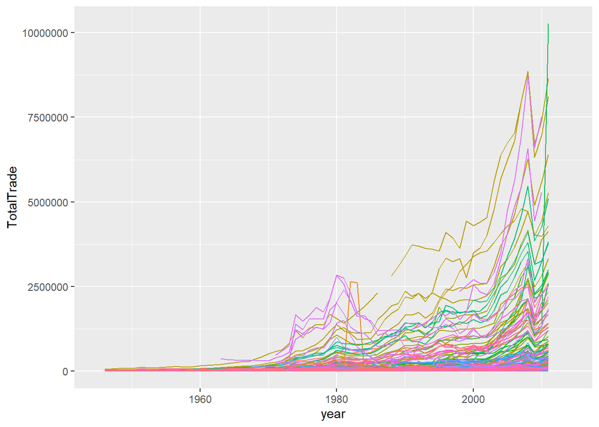

```r
ggplot(pddf , aes(x = as.Date(paste0(YearNumeric, "-01-01")), y = TotalTrade, colour = CountryCode )) +
  geom_line() +
  labs(x = "year") +
  theme(legend.position="none")
```

Both predictors are highly autocorrelated, which should not be ignored in the model specification.

```r
PL <- pdwtest(PercentLiterate~1,data=pddf)
UE <- pdwtest(UnivEnrollmentPerK~1,data=pddf)

rhos<-data.frame(Variable=c("PercentLiterate","UnivEnrollmentPerK"),
                 Rho = c(1-(PL$statistic/2),1-(UE$statistic/2)))

rhos
```

```
##             Variable    Rho
## 1    PercentLiterate 0.9753
## 2 UnivEnrollmentPerK 0.9405
```

Durbin Watson Test implies also a high autocorrelation.

```r
pdwtest(OLS)
```

```
##
##  Durbin-Watson test for serial correlation in panel models
##
## data:  lntt ~ PercentLiterate + UnivEnrollmentPerK
## DW = 0.081, p-value <2e-16
## alternative hypothesis: serial correlation in idiosyncratic errors
```

```r
PraisWinsten <- panelAR(lntt~PercentLiterate+UnivEnrollmentPerK,data=pddf,panelVar="CountryCode",timeVar="YearNumeric",
              autoCorr="ar1",panelCorrMethod="none",
              rho.na.rm=TRUE)
```

PraisWinsten increases the $r^{2}$ to 0.7768. Normally, the coefficients in the Prais Winsten model should get smaller. In this case UnivEnrollmentPerK is getting smaller, but the PercentLiterate even gets a little bit bigger.

```r
summary(PraisWinsten)
```

```
##
## Panel Regression with AR(1) Prais-Winsten correction and homoskedastic variance
##
## Unbalanced Panel Design:
##  Total obs.:       6632 Avg obs. per panel 41.975
##  Number of panels: 158  Max obs. per panel 65
##  Number of times:  65   Min obs. per panel 1
##
## Coefficients:
##                    Estimate Std. Error t value Pr(>|t|)
## (Intercept)         8.26521    0.09625    85.9   <2e-16 ***
## PercentLiterate     0.03099    0.00128    24.2   <2e-16 ***
## UnivEnrollmentPerK  0.03132    0.00168    18.7   <2e-16 ***
## ---
## Signif. codes:  0 '***' 0.001 '**' 0.01 '*' 0.05 '.' 0.1 ' ' 1
##
## R-squared: 0.7768
## Wald statistic: 1432.1929, Pr(>Chisq(2)): 0
```

The PCSE model results with the same coefficients and $r^{2}$ but the standard errors look different.

```r
PCSE<-panelAR(lntt~PercentLiterate+UnivEnrollmentPerK,data=pddf,panelVar="CountryCode",timeVar="YearNumeric",
           autoCorr="ar1",panelCorrMethod="pcse",
           rho.na.rm=TRUE)

summary(PCSE)
```

```
##
## Panel Regression with AR(1) Prais-Winsten correction and panel-corrected standard errors
##
## Unbalanced Panel Design:
##  Total obs.:       6632 Avg obs. per panel 41.975
##  Number of panels: 158  Max obs. per panel 65
##  Number of times:  65   Min obs. per panel 1
##
## Coefficients:
##                    Estimate Std. Error t value Pr(>|t|)
## (Intercept)         8.26521    0.15359   53.81   <2e-16 ***
## PercentLiterate     0.03099    0.00228   13.61   <2e-16 ***
## UnivEnrollmentPerK  0.03132    0.00358    8.76   <2e-16 ***
## ---
## Signif. codes:  0 '***' 0.001 '**' 0.01 '*' 0.05 '.' 0.1 ' ' 1
##
## R-squared: 0.7768
## Wald statistic: 262.5527, Pr(>Chisq(2)): 0
```

```r
PraisWinstenPSAR1 <-panelAR(lntt~PercentLiterate+UnivEnrollmentPerK,data=pddf,panelVar="CountryCode",timeVar="YearNumeric",
           autoCorr="psar1",panelCorrMethod="none",
           rho.na.rm=TRUE)
```

When the model includes autocorrelation with a unique correlation coefficient for each panel the $r^{2}$ increases to 0.9594.

```r
summary(PraisWinstenPSAR1)
```

```
##
## Panel Regression with AR(1) Prais-Winsten correction and homoskedastic variance
##
## Unbalanced Panel Design:
##  Total obs.:       6632 Avg obs. per panel 41.975
##  Number of panels: 158  Max obs. per panel 65
##  Number of times:  65   Min obs. per panel 1
##
## Coefficients:
##                    Estimate Std. Error t value Pr(>|t|)
## (Intercept)        8.103519   0.055192   146.8   <2e-16 ***
## PercentLiterate    0.026856   0.000935    28.7   <2e-16 ***
## UnivEnrollmentPerK 0.038277   0.001562    24.5   <2e-16 ***
## ---
## Signif. codes:  0 '***' 0.001 '**' 0.01 '*' 0.05 '.' 0.1 ' ' 1
##
## R-squared: 0.9594
## Wald statistic: 3481.774, Pr(>Chisq(2)): 0
```

Usually it is expected that the coefficents would get smaller compared to an ols model. This is true for the UnivEnrollmentPerK Variable but not for the PercentLiterate.

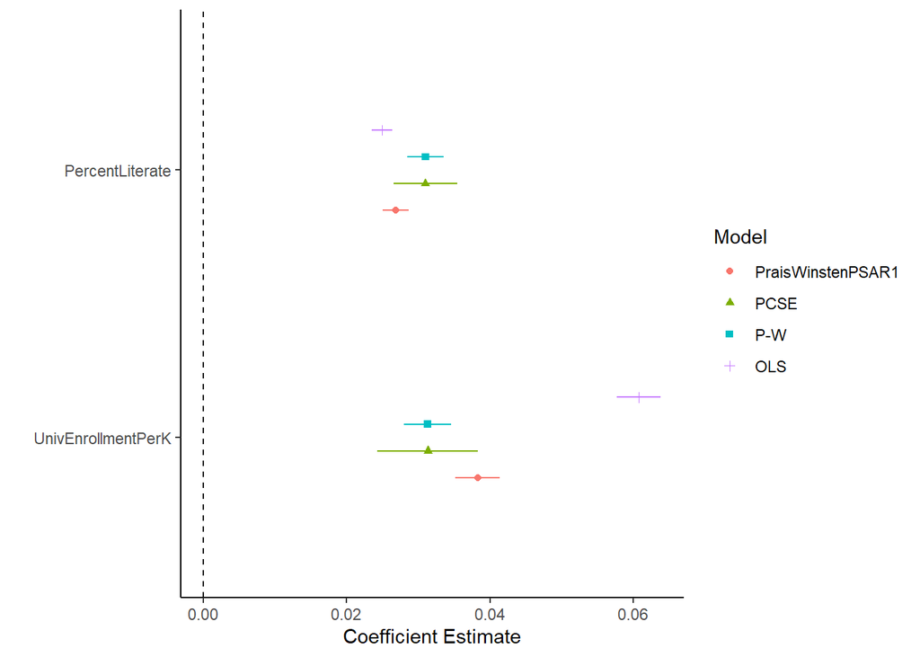

```r
hats <- data.frame(term=rep(c("(Intercept)","PercentLiterate",
                 "UnivEnrollmentPerK"),4),
                 model=c(rep("OLS",3),rep("P-W",3),               rep("PCSE",3),rep("PraisWinstenPSAR1",3)),
                 estimate=c(coef(OLS),coef(PraisWinsten),
                               coef(PCSE), coef(PraisWinstenPSAR1)),
                 std.error=c(sqrt(diag(vcov(OLS))),
                                 sqrt(diag(vcov(PraisWinsten))),

                                 sqrt(diag(vcov(PCSE))),
                                 sqrt(diag(vcov(PraisWinstenPSAR1))))
)


dwplot(hats,
       vline=geom_vline(xintercept=0,linetype=2),
       dot_args = list(aes(shape = model))) +
       theme_classic() +
       xlab("Coefficient Estimate") +
       guides(shape = guide_legend("Model"),
              colour = guide_legend("Model"))
```

#### Dynamic Models

```r
LDVfit <- lm(lntt~PercentLiterate+UnivEnrollmentPerK+lag(TotalTrade),data=pddf)

FDfit <- plm(lntt~PercentLiterate+UnivEnrollmentPerK,
              data=pddf,effect="individual",model="fd")

LDVFEfit <- plm(lntt~PercentLiterate+UnivEnrollmentPerK+lag(TotalTrade),data=pddf,effect="individual",model="within")

modelsummary(list(LDVfit,FDfit,FE.1way,LDVFEfit))
```

|  | Model 1 | Model 2 | Model 3 | Model 4 |
| --- | --- | --- | --- | --- |
| (Intercept) | 8.372 | 0.069 |  |  |
|  | (0.038) | (0.003) |  |  |
| PercentLiterate | 0.022 | −0.001 | 0.026 | 0.029 |
|  | (0.001) | (0.002) | (0.001) | (0.001) |
| UnivEnrollmentPerK | 0.038 | 0.007 | 0.077 | 0.059 |
|  | (0.001) | (0.002) | (0.001) | (0.001) |
| lag(TotalTrade) | 0.000 |  |  | 0.000 |
|  | (0.000) |  |  | (0.000) |
| Num.Obs. | 6632 | 6474 | 6632 | 6525 |
| R2 | 0.665 | 0.003 | 0.661 | 0.699 |
| R2 Adj. | 0.665 | 0.002 | 0.652 | 0.692 |
| AIC | 19977.8 | −3228.9 | 13693.9 | 12487.8 |
| BIC | 20011.8 | −3228.1 | 13696.7 | 12488.6 |
| RMSE | 1.09 | 0.19 | 0.68 | 0.63 |

#### Trends

```r
pddf$Trend <- ifelse(pddf$YearNumeric-1995>0, 0, pddf$YearNumeric-1995)

# FE with trend:

FE.trend <- plm(lntt ~ PercentLiterate + UnivEnrollmentPerK + Trend,
              data=pddf,effect="individual",
              model="within")

summary(FE.trend)
```

```
## Oneway (individual) effect Within Model
##
## Call:
## plm(formula = lntt ~ PercentLiterate + UnivEnrollmentPerK + Trend,
##     data = pddf, effect = "individual", model = "within")
##
## Unbalanced Panel: n = 158, T = 1-65, N = 6632
##
## Residuals:
##    Min. 1st Qu.  Median 3rd Qu.    Max.
## -2.9940 -0.3121 -0.0192  0.3137  4.1587
##
## Coefficients:
##                    Estimate Std. Error t-value Pr(>|t|)
## PercentLiterate    -0.00793    0.00080   -9.92   <2e-16 ***
## UnivEnrollmentPerK  0.03176    0.00106   29.97   <2e-16 ***
## Trend               0.06393    0.00102   62.95   <2e-16 ***
## ---
## Signif. codes:  0 '***' 0.001 '**' 0.01 '*' 0.05 '.' 0.1 ' ' 1
##
## Total Sum of Squares:    9010
## Residual Sum of Squares: 1900
## R-Squared:      0.789
## Adj. R-Squared: 0.784
## F-statistic: 8088.01 on 3 and 6471 DF, p-value: <2e-16
```

#### Orthogonalization

With the Orthogonalization approach it is visible that the coefficients are very small and very precise.

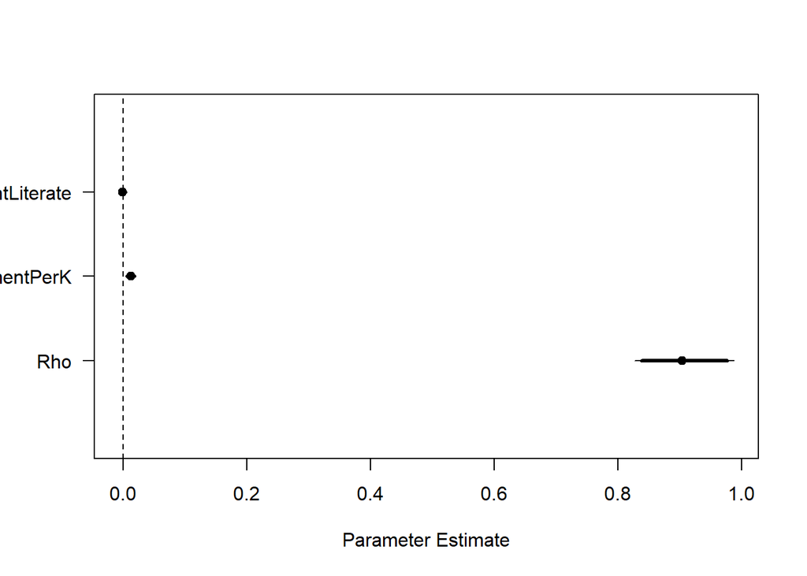

```r
set.seed(7222009)
OPM.fit <- opm(lntt ~ PercentLiterate + UnivEnrollmentPerK,
               data=pddf,index=c("CountryCode","Year"),n.samp=1000)

# Ladder plot of estimates & CIs:
caterplot(OPM.fit,parm=c("beta","rho"),
          main=c(""),xlab="Parameter Estimate",
          labels=c("PercentLiterate",
                   "UnivEnrollmentPerK","Rho"))
abline(v=c(0),lty=2)
```

### Conclusion

According to the models we can say that percentliterate and univenrollmentperk have a little effect on the totaltrade and there are probably more important predictors that are missing in these models.